# Project 3: Dynamic Programming

Har Jing Daryl

Goh Teng Wei

Koh Jun Kai

# (1) Recursive definition of the function P(C)

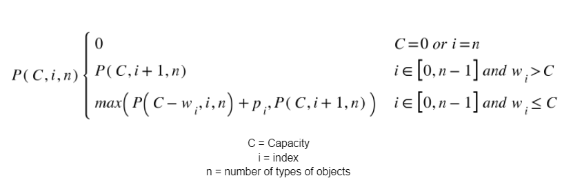

```python
def knapsack_recursive(c: int, item_index: int, weights: list, profits: list) -> int:
    # If the max capacity is 0 or we have run out of items to pick, return 0
    if c == 0 or item_index == len(profits):
        return 0

    # If the weight of the current item is more than maximum weight allowed, we cannot pick it,
    # so we move on to the next element.
    if weights[item_index] > c:
        return knapsack_recursive(c, item_index + 1, weights, profits)

    # We choose whether or not to pick the item.
    return max(
        # We pick the item
        knapsack_recursive(c - weights[item_index], item_index, weights, profits) + profits[item_index],
        # We do not pick the item
        knapsack_recursive(c, item_index + 1, weights, profits)
    )
```

# (2) Draw the subproblem graph for P(14) where n is 3 with the weights and profits given below

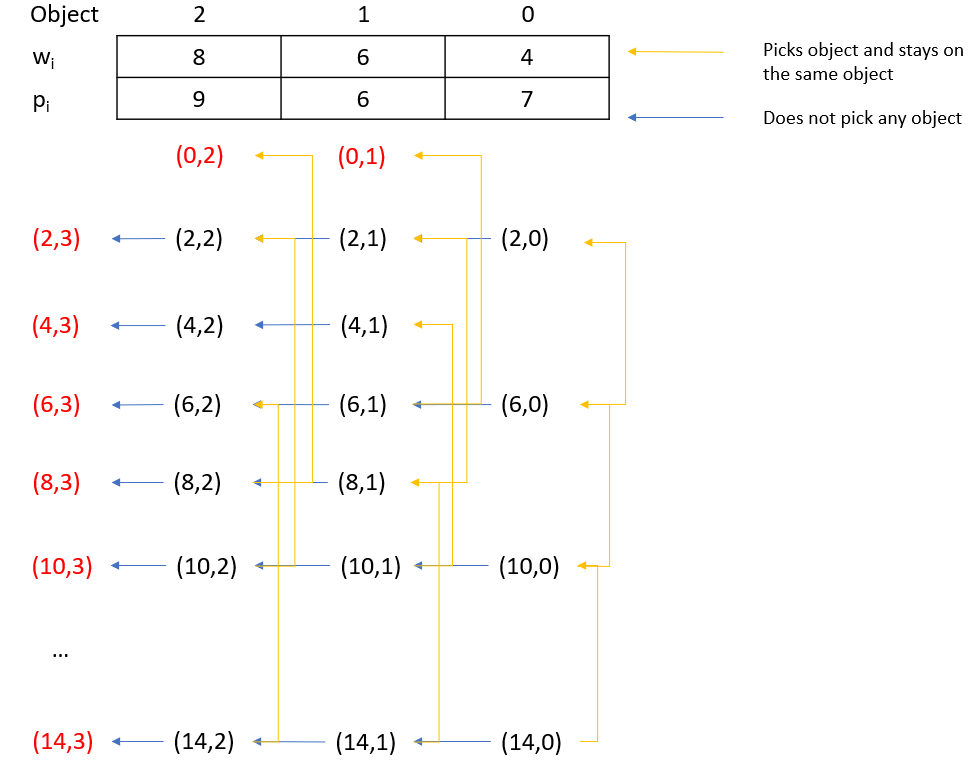

# (3) Give a dynamic programming algorithm to compute the maximum profit, given a knapsack of capacity C, n types of objects with weights w<sub>i</sub> and profits p<sub>i</sub> using the bottom up approach.

# Method 1: Using 2D array

```python
def knapsack_dynamic2D(C: int, n: int, weight: list, profit: list) -> int:

    # Creates a list containing C+1 lists, each of n+1 items, all set to 0
    # Initialise 2D array of dimensions (C+1 , n+1) to keep track of max profit
    matrix = [[0 for x in range(n+1)] for y in range(C+1)]

    # Initialise first column to 0
    for r in range (1, C+1):
        matrix[r][0] = 0

    # Initialise first row to 0
    for c in range(n+1):
        matrix[0][c] = 0

    # r represents the capacity available
    for r in range(1, C+1):
        # c represents the index of the current object
        for c in range(1, n+1):

            # Index of weight and profit arrays
            index = c-1

            # Default value of matrix[r][c] is to the left of it (ie minus 1 column)
            matrix[r][c] = matrix[r][c-1]

            # If weight of current object is less than the available capacity,
            # then we can choose whether we want to pick the current object
            if (weight[index] <= r):
                # If profit of not picking an object is less than profit of picking an object and move to next/pick and stay
                if (matrix[r][c] < max(matrix[r-weight[index]][c-1] + profit[index] ,
                                            matrix[r-weight[index]][c] + profit[index])):
                    # Compare the max profit between picking an object and moving to the next object,
                    # and picking an object and staying on the same object
                    matrix[r][c] = max(matrix[r-weight[index]][c-1] + profit[index] ,
                                            matrix[r-weight[index]][c] + profit[index])

   # Printing out matrix values
    for i in range(C+1):
        print()
        print(i, end=" : ")
        for j in range(n+1):
            print(str(matrix[i][j]),end=" | ")
    print()

    # Returns the bottom left of matrix for max profit
    return matrix[C][n]
```

# Method 2: Using 1D array

```python
def knapsack_dynamic1D(C: int, n: int, weight: list, profit: list) -> int:
    # Initialise 1D array of size capacity + 1
    # Usage of 1D array is possible because there are unlimited number of each objects
    # So we do not have to keep track of which object is used at which instance
    array = [0 for x in range(C+1)]

    # For each capacity c, we will determine the max profit from the objects available for picking.
    for c in range(C+1):
        # We attempt to find the max profit by iterating through all objects and tracking their max profit.
        for object_index in range(n):
            # If weight of current object is less than or equal to the capacity available,
            # then we are able to choose whether to pick this object again or not.
            if weight[object_index] <= c:
                # We compare the profit between the current profit, and the profit from picking the current
                # object again.
                array[c] = max(
                    # The current max profit for this capacity.
                    array[c],
                    # Profit for if we pick this object and then add it with the max profit of the capacity
                    # after we subtract the current items' weight.
                    array[c - weight[object_index]] + profit[object_index]
                )

    print()
    print("The values of the 1D array is: " + str(array))
    return array[C]
```

# (4) a. show the running result of P(14) with weights and profits given in (2)

```python
print("The weights for the objects are: " + str(weight1))

print("The profits for the objects are: " + str(profit))

print("The maximum profit for recursive programming is: " + str(knapsack_recursive(14,0,weight1,profit)))
print("The maximum profit for dynamic programming using 2D array is: " + str(knapsack_dynamic2D(14,len(profit),weight1,profit)))
print("The maximum profit for dynamic programming using 1D array is: " + str(knapsack_dynamic1D(14,len(profit),weight1,profit)))
```

```
The weights for the objects are: [4, 6, 8]
The profits for the objects are: [7, 6, 9]
The maximum profit for recursive programming is: 21

0 : 0 | 0 | 0 | 0 |
1 : 0 | 0 | 0 | 0 |
2 : 0 | 0 | 0 | 0 |
3 : 0 | 0 | 0 | 0 |
4 : 0 | 7 | 7 | 7 |
5 : 0 | 7 | 7 | 7 |
6 : 0 | 7 | 7 | 7 |
7 : 0 | 7 | 7 | 7 |
8 : 0 | 14 | 14 | 14 |
9 : 0 | 14 | 14 | 14 |
10 : 0 | 14 | 14 | 14 |
11 : 0 | 14 | 14 | 14 |
12 : 0 | 21 | 21 | 21 |
13 : 0 | 21 | 21 | 21 |
14 : 0 | 21 | 21 | 21 |
The maximum profit for dynamic programming using 2D array is: 21

The values of the 1D array is: [0, 0, 0, 0, 7, 7, 7, 7, 14, 14, 14, 14, 21, 21, 21]
The maximum profit for dynamic programming using 1D array is: 21
```

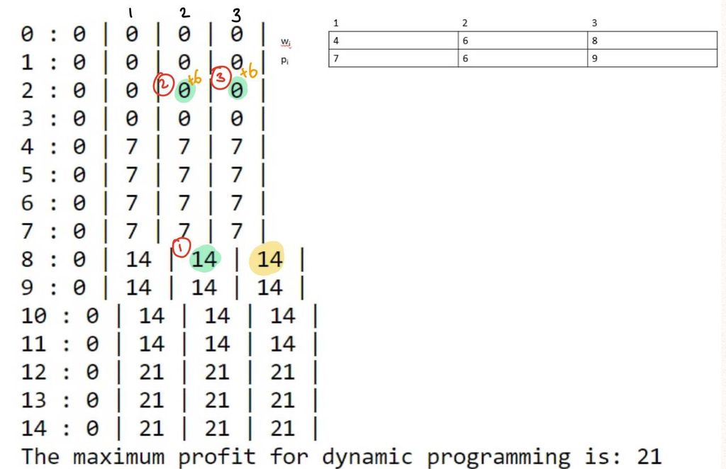

Consider `r=8`, `c=3`, `index=2`

**Option(1)**: matrix[r][c-1] = `matrix[8][2]` = **14**

`array[r] = max(array[r] , array[r-weight[c]]+profit[c]`

**(1)** Consider `r=4`  
For the capacity `4`, only object 0 with weight 4 is available.  
array[4] = max(array[4], array[4 - weight[0]] + profit[0]) = max(array[4], array[0] + profit[0]) = `max(0, 0+7)` = 7

Therefore, `array[4]` = **7**

**(2)** Consider `r=8`  
For the capacity `8`, **all three objects are available.** Hence, we iterate through every object starting from object 0.

**Iteration 1**: array[8] = max(array[8], array[8 - weight[0]] + profit[0]) = max(array[8], array[4] + profit[0]) = `max(0, 7+7)` = 14

**Iteration 2**: array[8] = max(array[8], array[8 - weight[1]] + profit[1]) = max(array[8], array[2] + profit[1]) = `max(14, 0+6)` = 14

**Iteration 3**: array[8] = max(array[8], array[8 - weight[2]] + profit[2]) = max(array[8], array[0] + profit[2]) = `max(14, 0+9)` = 14

Therefore, `array[8]` = **14**

# (4) b. Show the running result of P(14) with weights and profits given below.

```python
print("The weights for the objects are: " + str(weight2))

print("The profits for the objects are: " + str(profit))

print("The maximum profit for recursive programming is: " + str(knapsack_recursive(14,0,weight2,profit)))
print("The maximum profit for dynamic programming using 2D array is: " + str(knapsack_dynamic2D(14,len(profit),weight2,profit)))
print("The maximum profit for dynamic programming using 1D array is: " + str(knapsack_dynamic1D(14,len(profit),weight2,profit)))
```

```
The weights for the objects are: [5, 6, 8]
The profits for the objects are: [7, 6, 9]
The maximum profit for recursive programming is: 16

0 : 0 | 0 | 0 | 0 |
1 : 0 | 0 | 0 | 0 |
2 : 0 | 0 | 0 | 0 |
3 : 0 | 0 | 0 | 0 |
4 : 0 | 0 | 0 | 0 |
5 : 0 | 7 | 7 | 7 |
6 : 0 | 7 | 7 | 7 |
7 : 0 | 7 | 7 | 7 |
8 : 0 | 7 | 7 | 9 |
9 : 0 | 7 | 7 | 9 |
10 : 0 | 14 | 14 | 14 |
11 : 0 | 14 | 14 | 14 |
12 : 0 | 14 | 14 | 14 |
13 : 0 | 14 | 14 | 16 |
14 : 0 | 14 | 14 | 16 |
The maximum profit for dynamic programming using 2D array is: 16

The values of the 1D array is: [0, 0, 0, 0, 0, 7, 7, 7, 9, 9, 14, 14, 14, 16, 16]
The maximum profit for dynamic programming using 1D array is: 16
```